# Midpoint Project

Meli Akdeniz

5/24/2019

## Introduction

Music is at the root of of the lives of the majority of people. Mostly as a point of leisure and a means of escape from the stress of the real world. Breaking down todays popular songs gives insight into the musical components that make up these songs of escape for the listerns of Spotify. This projects develves into what makes a song popular and what features are the features of a popular song. Music listened is a form of self-expression and looking into popular in specific offers a lot of insight into a culture. Analyzing data sets found for the top 100 songs on Spotify from 2017 and 2018 each song is broken into several different musical components. These include: danceability – how danceable a song is based on combination of musical elements such as tempo, rhythym stability, beat strength, and regularity 0 is least danceable, and 1 is most danceable. energy – measure of intensity and activity, 1 is fast, loud and noisy key – the estimated key of the track, if no key detected the value is -1 loudness – how loud a track is in decibels, range from -60 to 0 db mode – indicate the type of scale from which the melodic content derived, major is 1 and minor is 0 speechiness – measure of presence of spoken words in track, from 0 to 1 0.66 and above is all spoken words, 0.33-0.66 is music and speech, and below 0.33 is music accousticness – a confidence measure of whether a track is acoustic, from 0 to 1. instrumental – measure of vocals, closer to 1, means less vocal content liveness – detects the presence of an audience in the recording. Higher liveness values represent an increased probability of a live recording. a value above 0.8 provides strong likelihood that the track is live. tempo – measure of beats per minute(BPM), speed or pace of song

## Summary Information

In 2017, Pop was/were the most popular genre(s), and Ed Sheeran, The Chainsmokers was/were the most popular artist(s). The most danceable song(s) was/were Bad and Boujee (feat. Lil Uzi Vert), Fake Love. The average danceability of the top 100 songs in 2017 was 0.69682. The average danceability of the most popular genre of the top 100 songs of 2017 was 0.6886562. In 2018, Hip-Hop/Rap was/were the most popular genre(s), and Post Malone, XXXTENTACION was/were the most popular artist(s). The most danceable song(s) was/were Yes Indeed. The average danceability of the top 100 songs in 2018 was 0.71646. The average danceability of the most popular genre of the top 100 songs of 2018 was 0.7590667.

## What is the distribution for speechiness(measure of spoken words) in the most popular genre for both 2017 and 2018?

The two following charts show a distribution of speechiness for the most popular genre for 2017 and 2018.It can be seen that for both years speechiness does not go above 0.6, indicating that neither genre contains all spoken words for the top 100 songs for both years. In addition it can be seen that for the most popular genre for 2017, Pop, the frequency of low speechiness is much higher than for the speechiness for the most popular genre for 2018, Hip-Hop/Rap, indicating that Pop does not have much spoken words and has much more music. For Pop, majority of the data is centered below a speechiness of 0.2, indicating pop is mostly music compared to words. The plot for Hip-Hop Rap is much more dense from speechiness 0.1 to 0.3 compared to the plot for Pop indicating that Hip-Hop/Rap contains more words than Pop.

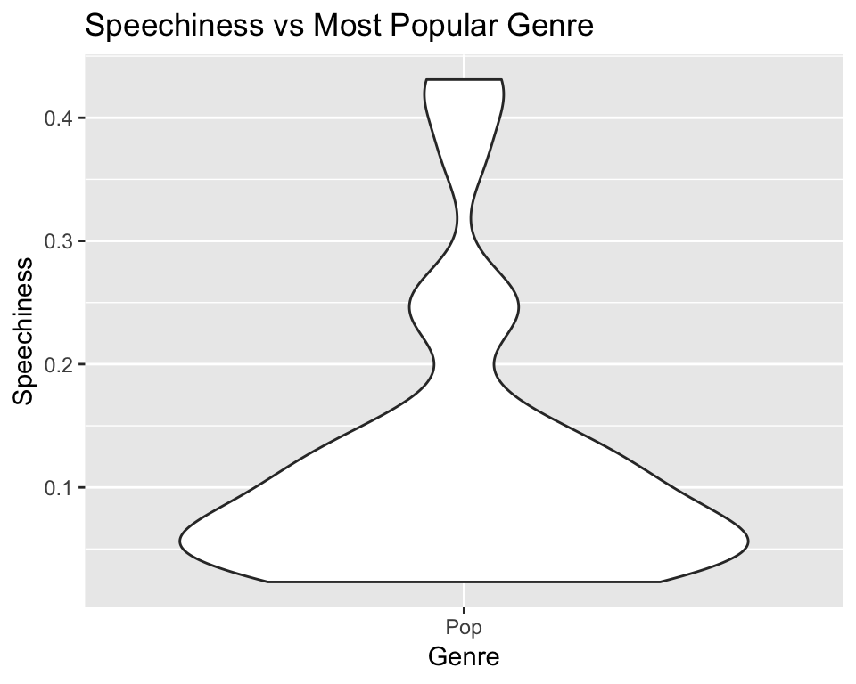

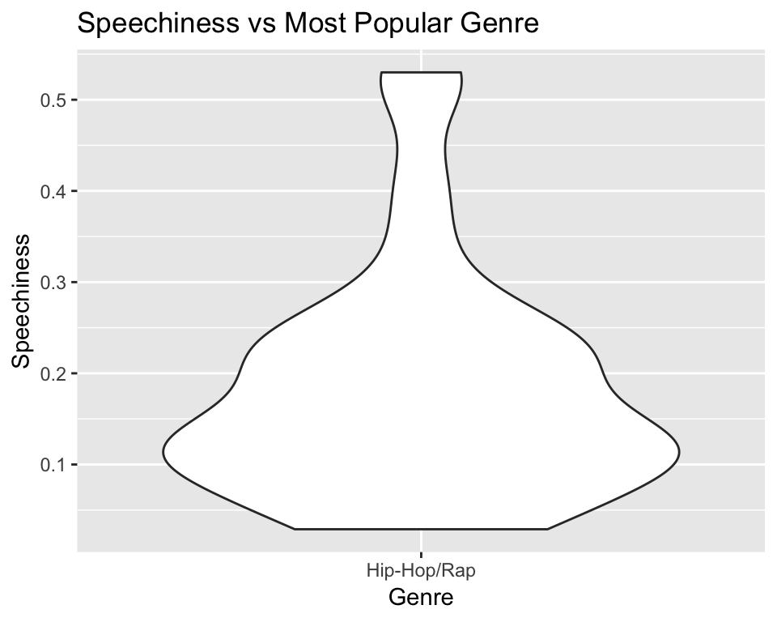